# Homework 2

MERVE ÜNAL- IE582 - Fall 2018 - 2016702108

26 Ekim 2018

**1-Introduction**

In this second assignment, i would like to share with you the answers of 3 tasks consecutively.

**TASK 1**

**A)**

**For bet365**

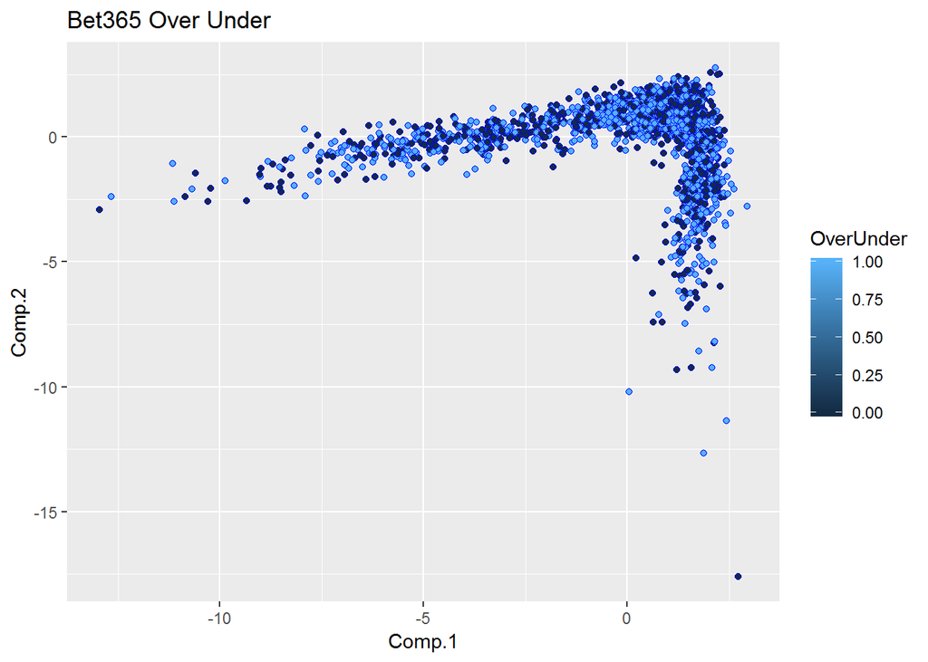

**bwin**

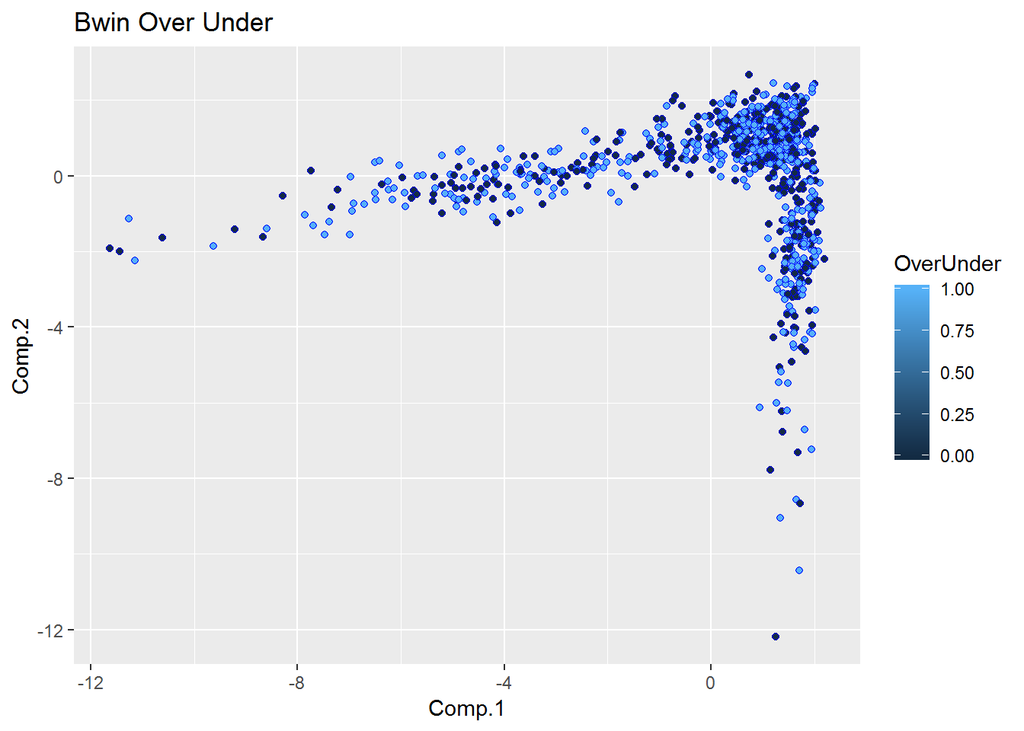

As can be seen on the graph, there are 2 groups, which are Over 2.5 and Under 2.5. Over 2.5 is represented by light blue and Under 2.5 is represented by dark blue. Also, i want to add an ellipse showing the intense area for the points. However, there are not two different seperation representing under 2.5 and over 2.5. In other words, these are not distributed different areas on graph. They are nearly same structure.Due to the fact that range of ove variable is not larger than another, PCA is meaningful.

**FOR 10bet**

[figure not shown]

As can be seen on the graph, there are 2 groups, which are Over 2.5 and Under 2.5. Over 2.5 is represented by light blue and Under 2.5 is represented by dark blue. However, there are not two different seperation representing under 2.5 and over 2.5. In other words, these are not distributed different areas on graph. They are nearly same structure.Due to the fact that range of ove variable is not larger than another, PCA is meaningful.

**BETVICTOR**

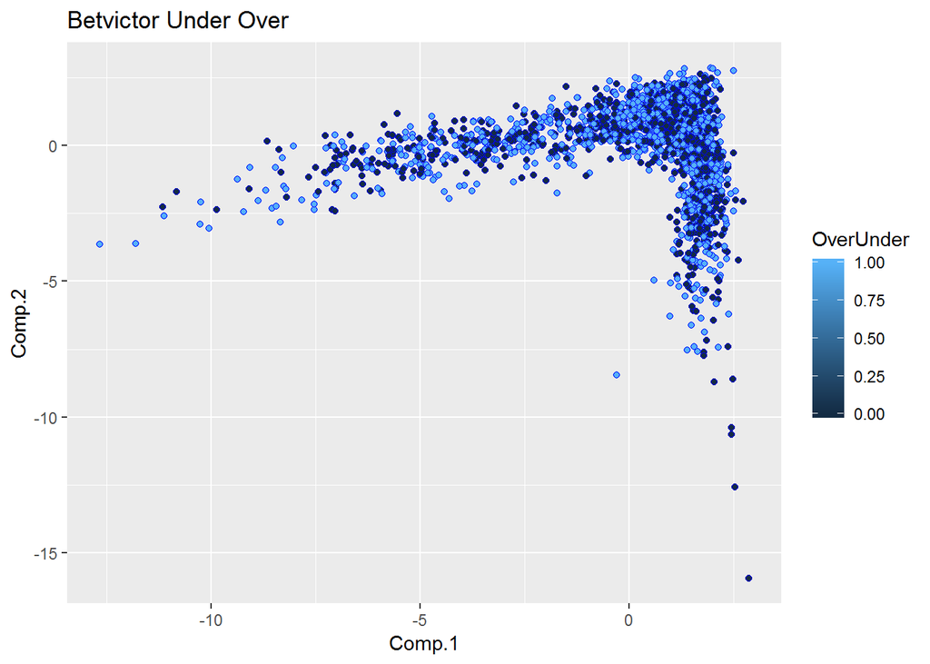

**betway**

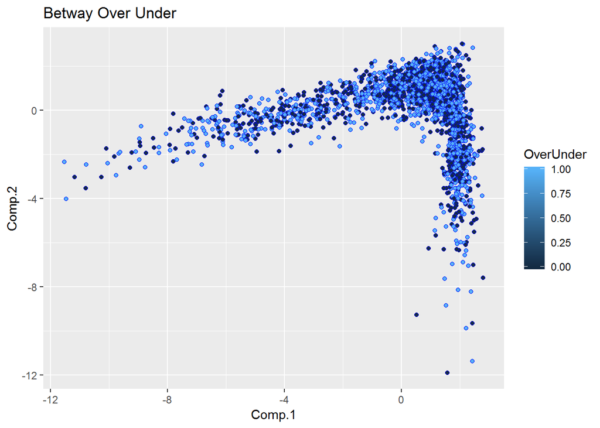

**B)**

**bet365**

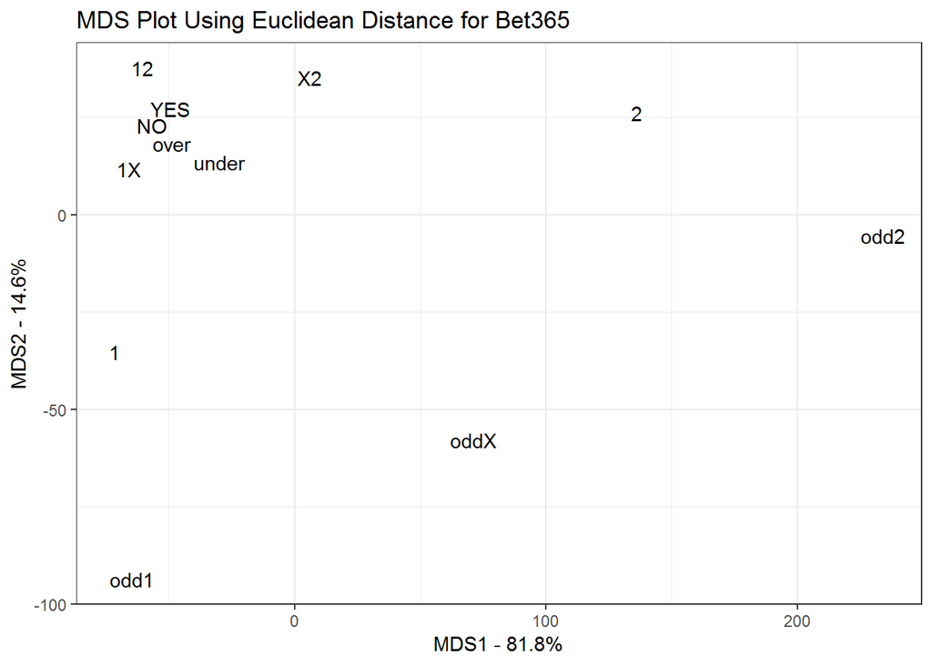

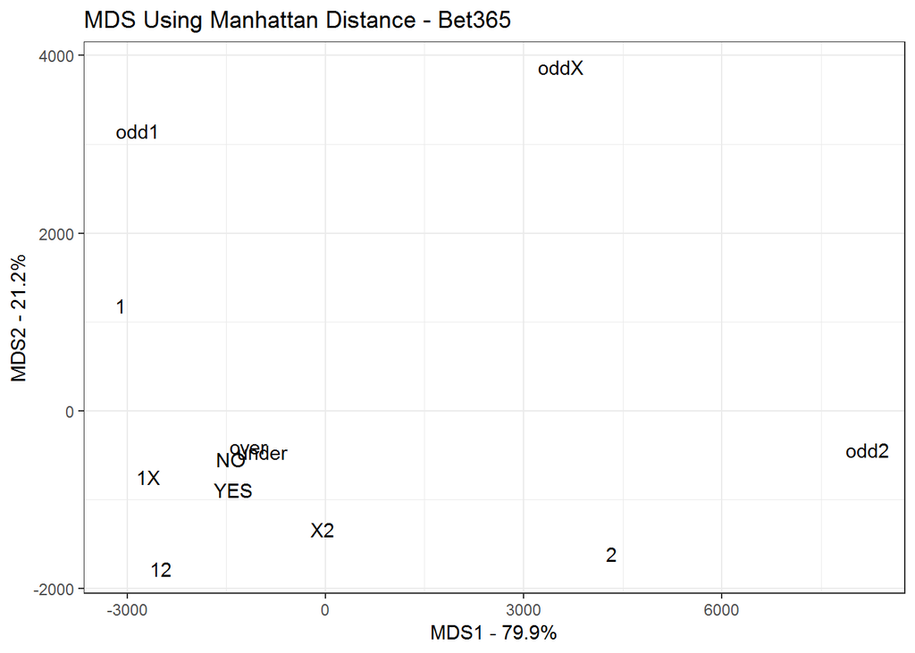

According to MDS plot using Euclidean distance and Manhattan distance, these graphs are almost same. They are not so different from each other, which is a good thing for us. Since it demonstrates how strong they are in terms of multidimensional scaling.

**bwin**

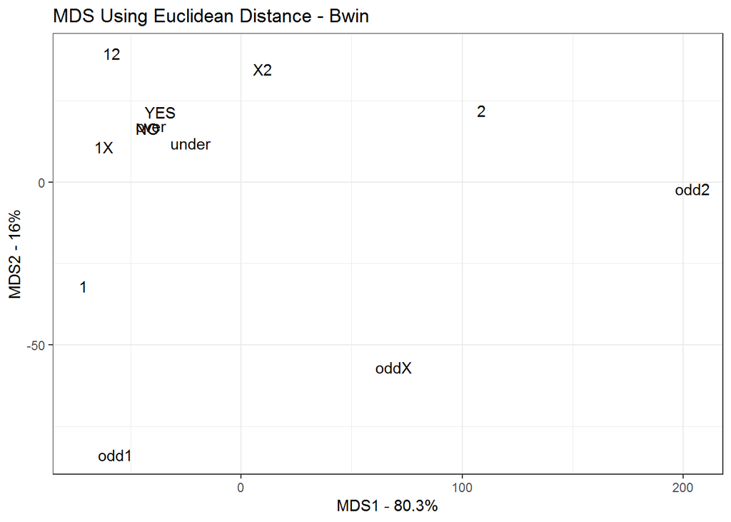

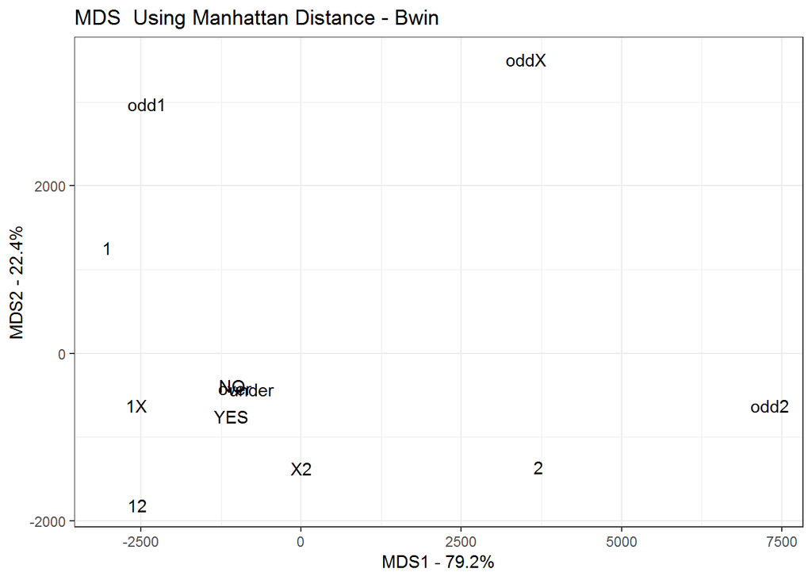

**10bet**

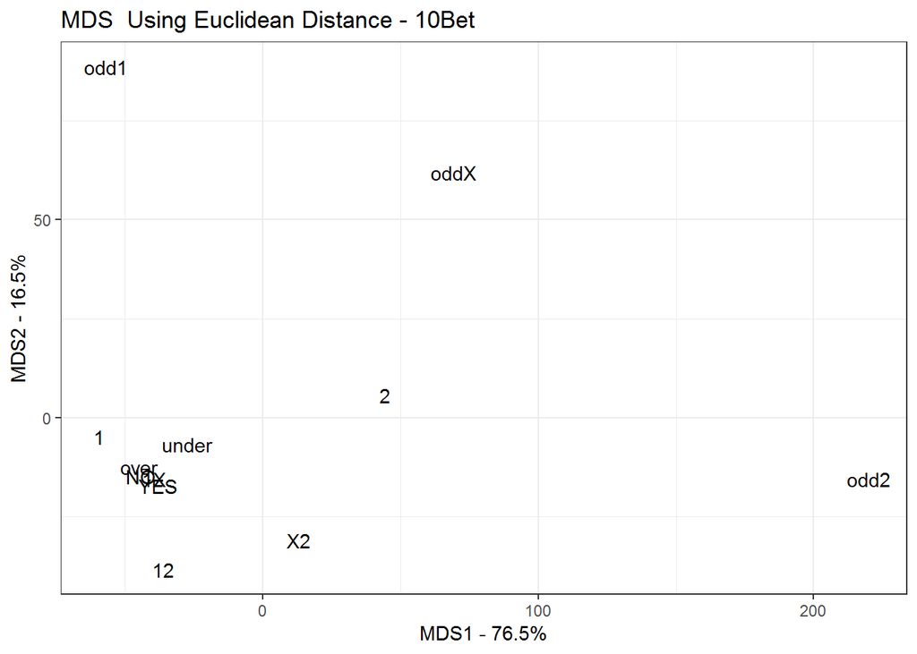

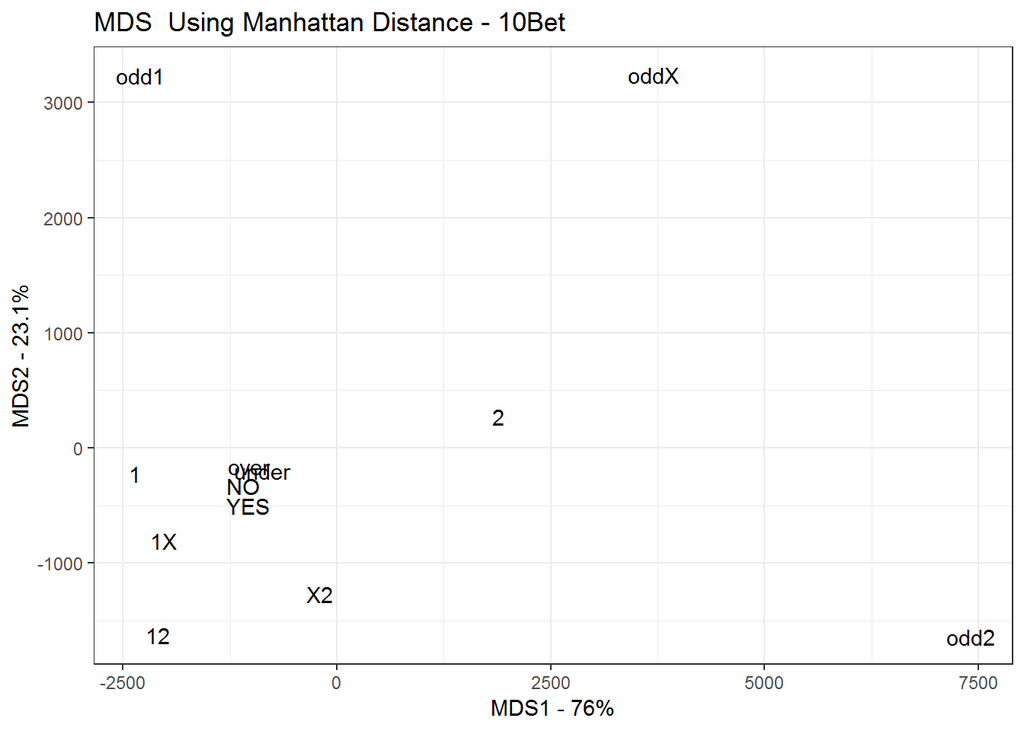

**betvictor**

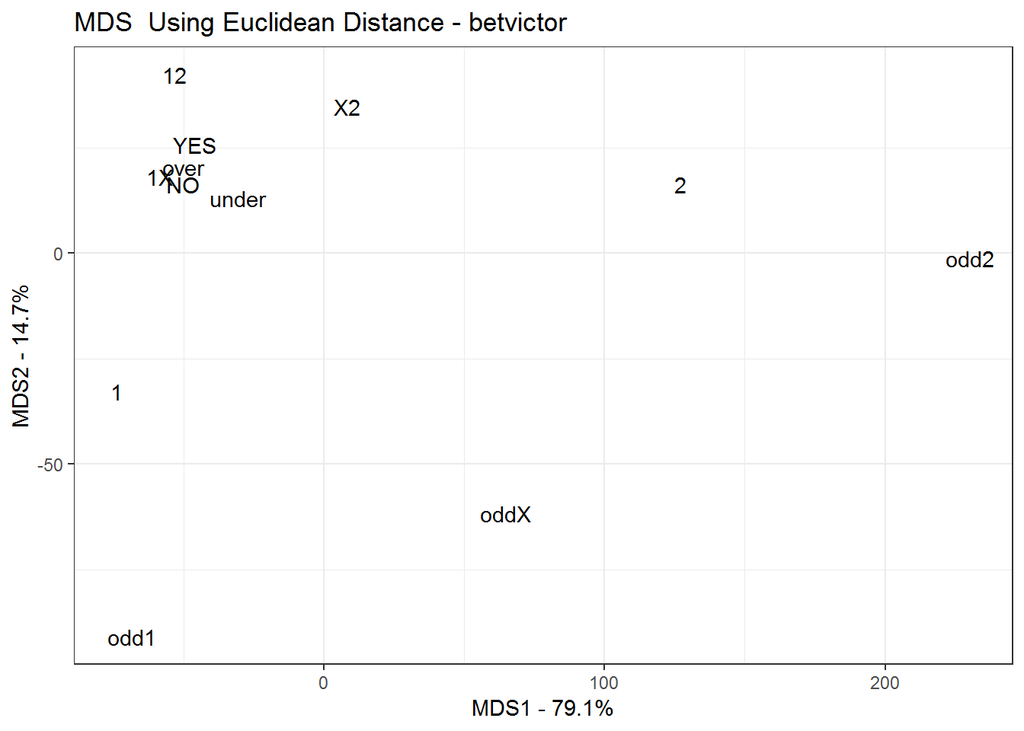

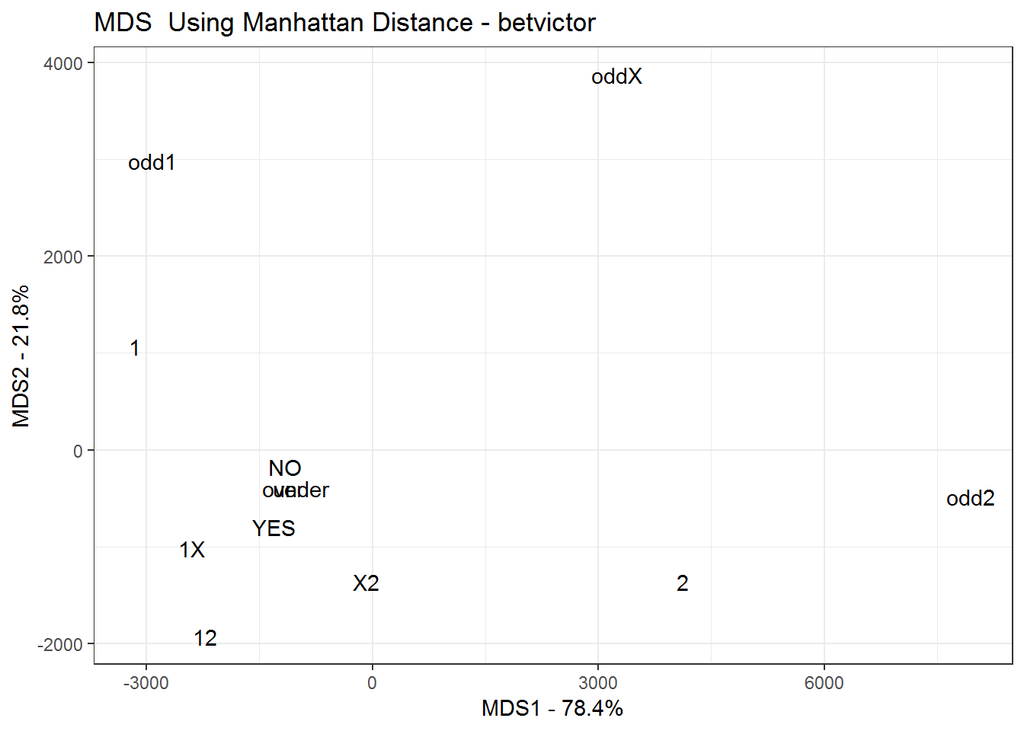

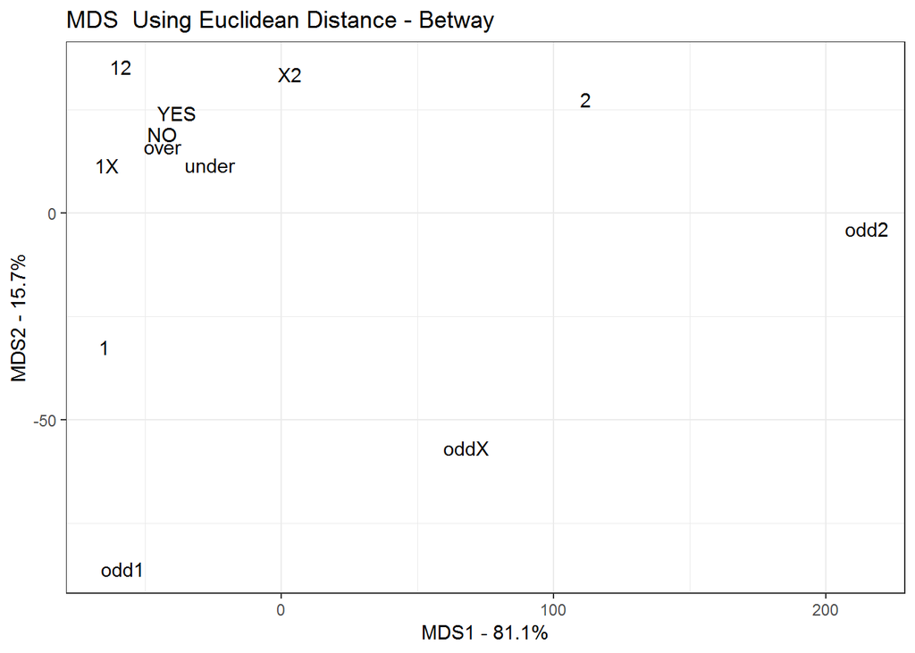

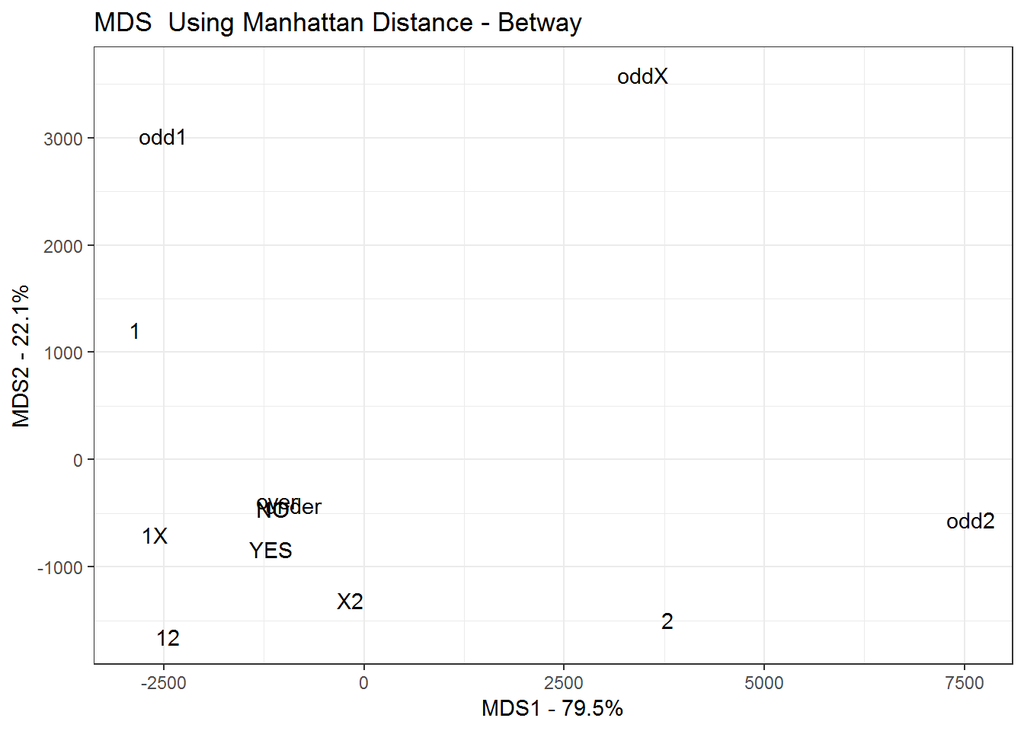

**TASK 2**

**For bet365**

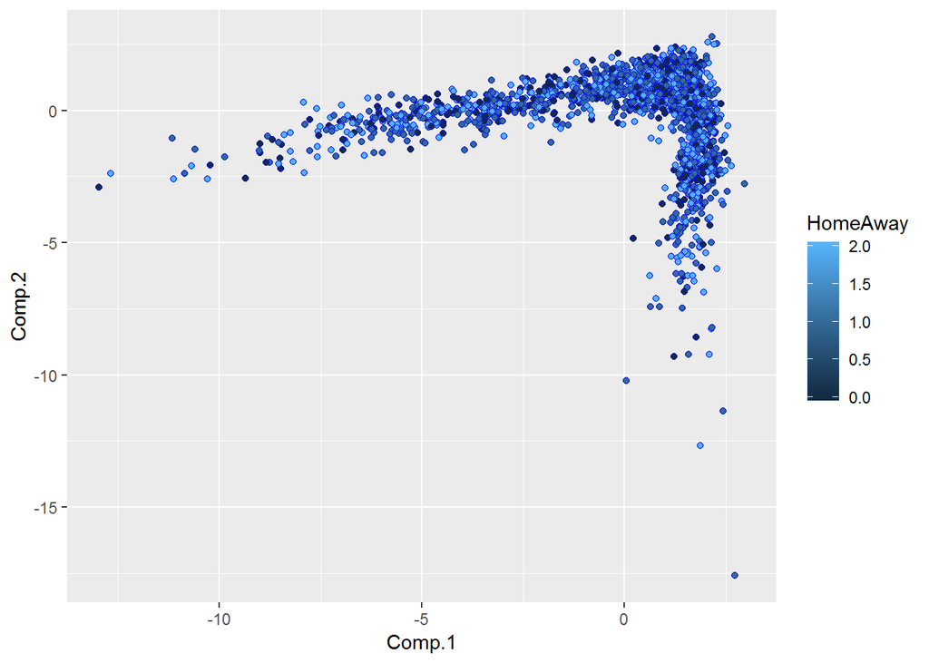

In this part’s Principal Component Analysis is exactly the same as task 1’s PCA result for particular bookmaker. Because the odd values for each odd type is the same. Due to the fact that the analysis is done in an unsupervised way the analysis does not include y response variable. Therefore, the features that are used in this analysis are the odd values only for the odd types for the bookmaker. So, PCA result for task 2 and PCA result for Task 1 is the same.

As can be seen on the graph, there are 3 groups, which are Home, Away and Tie. Away is represented by the lightest blue and Home is represented by the second lighest blue. Tie is represented by dark blue. . These are not distributed different areas on graph. They are nearly same structure. Also, it can be said from the graph that they are orthogonal to each other. Namely, their dot product is zero. The most intensity of proportion in terms of its colours belongs to Home.

**Bwin**

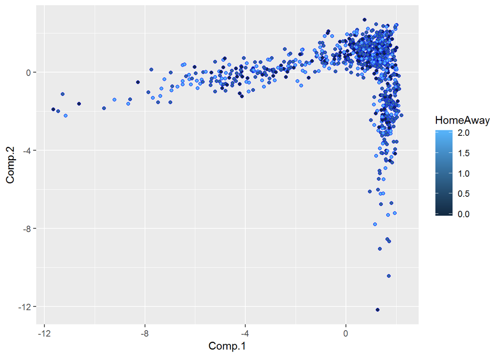

In this part’s Principal Component Analysis is exactly the same as task 1’s PCA result for particular bookmaker. Because the odd values for each odd type is the same. Due to the fact that the analysis is done in an unsupervised way the analysis does not include y response variable. Therefore, the features that are used in this analysis are the odd values only for the odd types for the bookmaker. So, PCA result for task 2 and PCA result for Task 1 is the same. As can be seen on the graph, there are 3 groups, which are Home, Away and Tie. Away is represented by the lightest blue and Home is represented by the second lighest blue. Tie is represented by dark blue. . These are not distributed different areas on graph. They are nearly same structure. Also, it can be said from the graph that they are orthogonal to each other. Namely, their dot product is zero. The most intensity of proportion in terms of its colours belongs to Home. **10Bet**

[figure not shown]

In this part’s Principal Component Analysis is exactly the same as task 1’s PCA result for particular bookmaker. Because the odd values for each odd type is the same. Due to the fact that the analysis is done in an unsupervised way the analysis does not include y response variable. Therefore, the features that are used in this analysis are the odd values only for the odd types for the bookmaker. So, PCA result for task 2 and PCA result for Task 1 is the same. As can be seen on the graph, there are 3 groups, which are Home, Away and Tie. Away is represented by the lightest blue and Home is represented by the second lighest blue. Tie is represented by dark blue. . These are not distributed different areas on graph. They are nearly same structure. Also, it can be said from the graph that they are orthogonal to each other. Namely, their dot product is zero. The most intensity of proportion in terms of its colours belongs to Home. Due to the fact that the range of one variable is not larger than the other, PCA is meaningful. **betvictor**

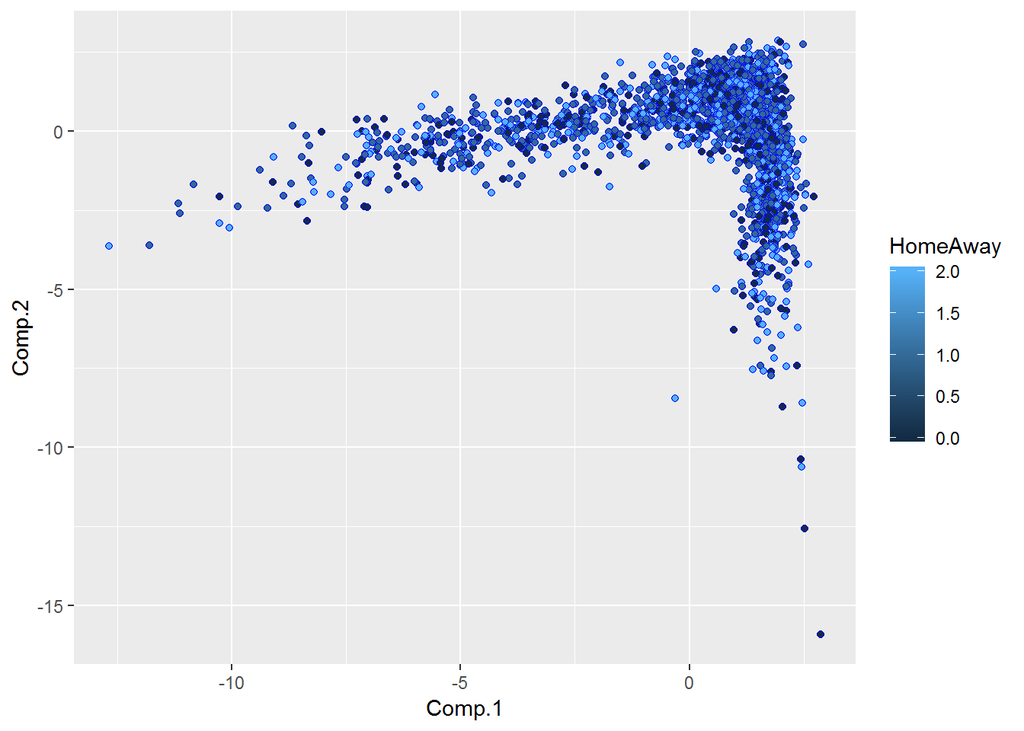

In this part’s Principal Component Analysis is exactly the same as task 1’s PCA result for particular bookmaker. Because the odd values for each odd type is the same. Due to the fact that the analysis is done in an unsupervised way the analysis does not include y response variable. Therefore, the features that are used in this analysis are the odd values only for the odd types for the bookmaker. So, PCA result for task 2 and PCA result for Task 1 is the same. As can be seen on the graph, there are 3 groups, which are Home, Away and Tie. Away is represented by the lightest blue and Home is represented by the second lighest blue. Tie is represented by dark blue. . These are not distributed different areas on graph. They are nearly same structure. Also, it can be said from the graph that they are orthogonal to each other. Namely, their dot product is zero. The most intensity of proportion in terms of its colours belongs to Home. **betway**

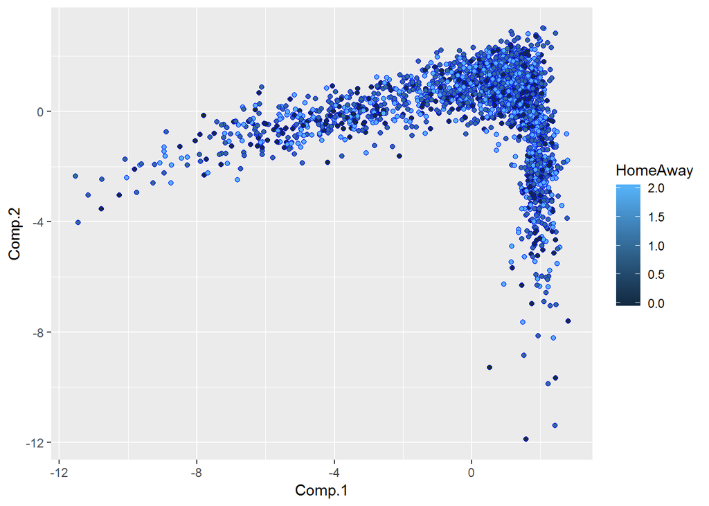

In this part’s Principal Component Analysis is exactly the same as task 1’s PCA result for particular bookmaker. Because the odd values for each odd type is the same. Due to the fact that the analysis is done in an unsupervised way the analysis does not include y response variable. Therefore, the features that are used in this analysis are the odd values only for the odd types for the bookmaker. So, PCA result for task 2 and PCA result for Task 1 is the same.

As can be seen on the graph, there are 3 groups, which are Home, Away and Tie. Away is represented by the lightest blue and Home is represented by the second lighest blue. Tie is represented by dark blue. . These are not distributed different areas on graph. They are nearly same structure. Also, it can be said from the graph that they are orthogonal to each other. Namely, their dot product is zero. The most intensity of proportion in terms of its colours belongs to Home. Due to the fact that the range of one variable is not larger than the other, PCA is meaningful. **TASK 3**

**1)**

**2)**

**A)**

Structure of the variable that stores the image and dimension can be seen with “str” function

```
##  num [1:200, 1:200, 1:3] 0.804 0.8 0.8 0.8 0.804 ...
```

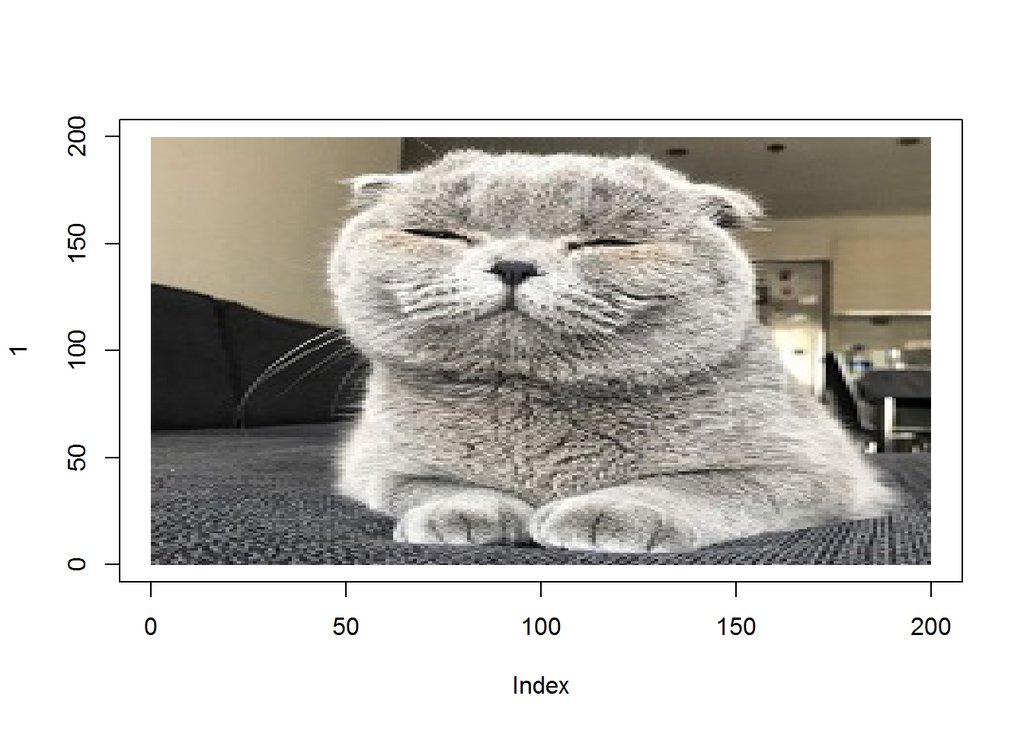

**B)**

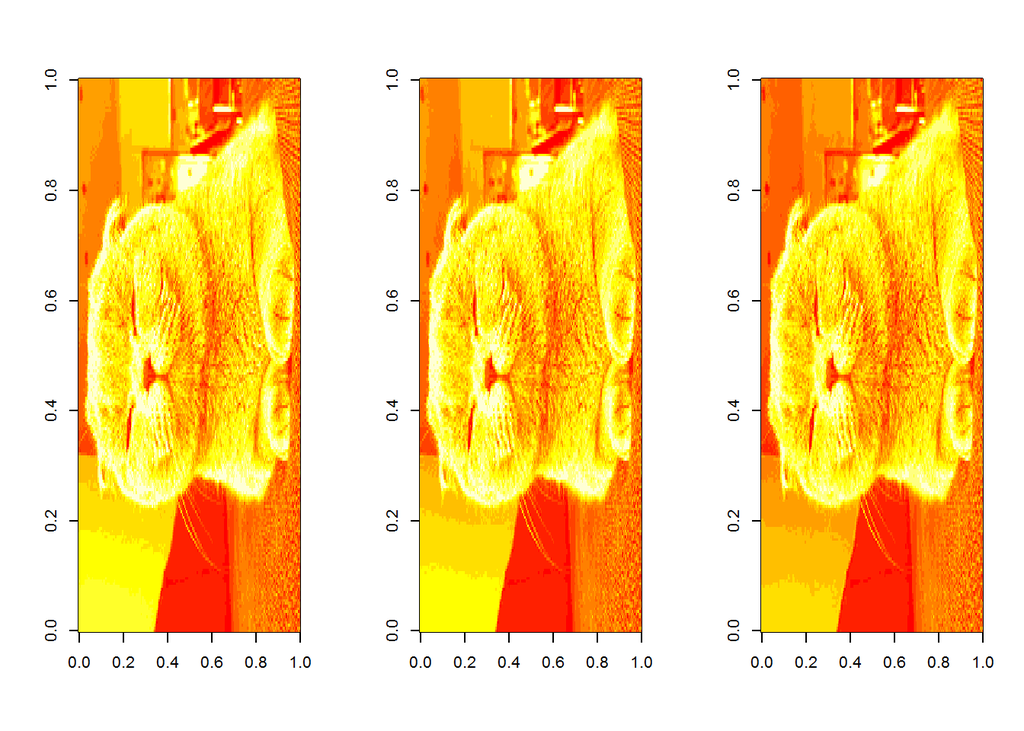

**3)**

**A)**

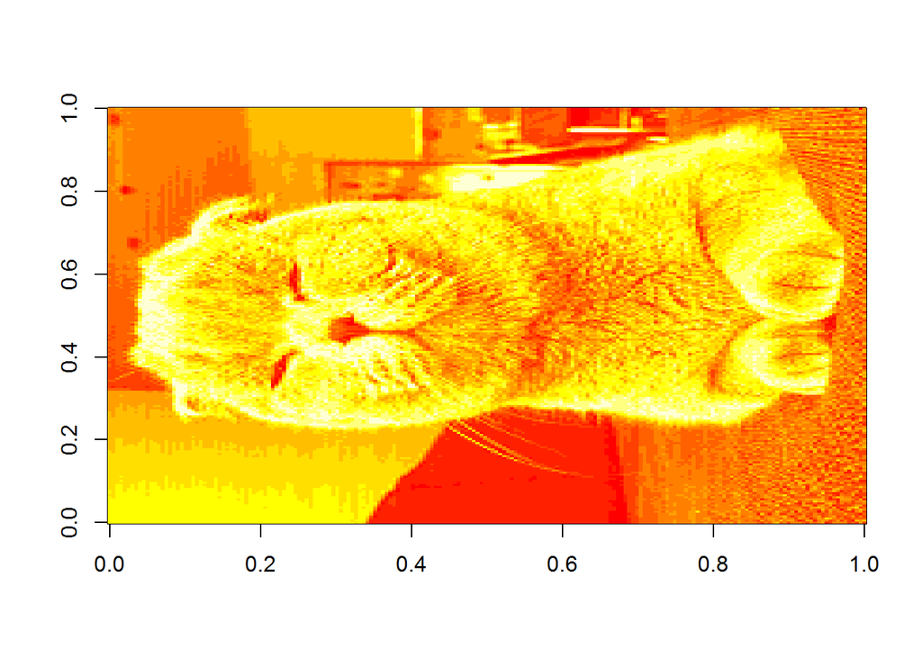

**B)**

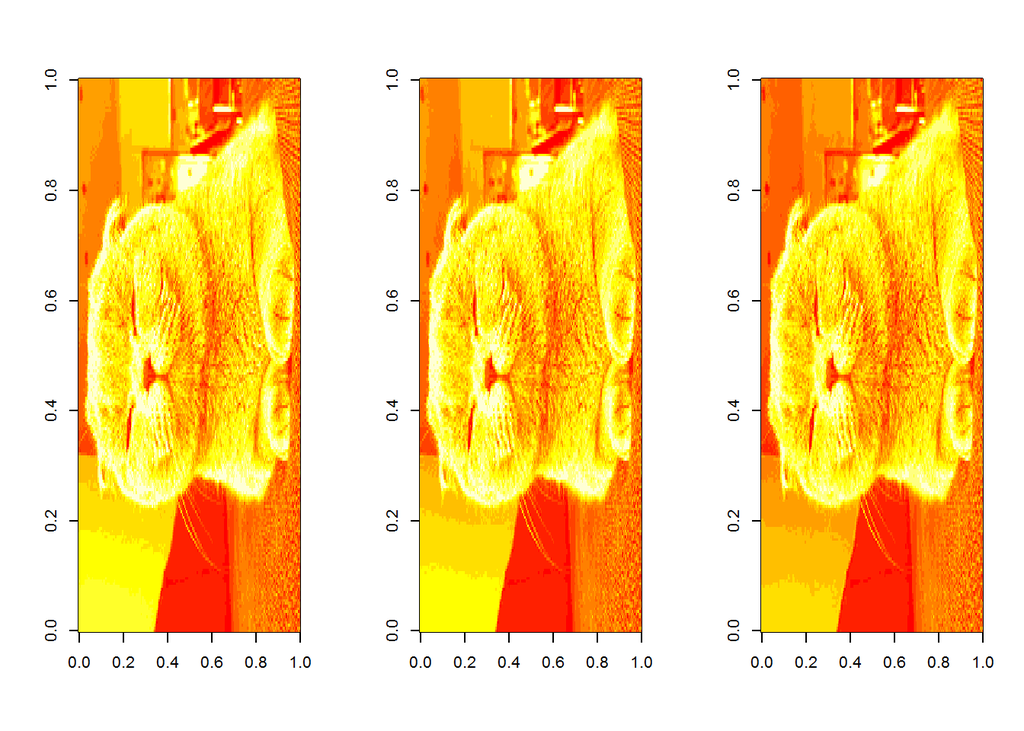

**TASK 4**

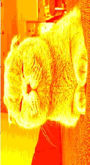

**3.CODES** **TASK 1**

odds <- readRDS(“C:/Users/Merve/Desktop/2018-2019 1.dönem/IE582/2.WEEK/df9b1196-e3cf-4cc7-9159-f236fe738215_odd_details.rds”)

matches <- readRDS(“C:/Users/Merve/Desktop/2018-2019 1.dönem/IE582/2.WEEK/df9b1196-e3cf-4cc7-9159-f236fe738215_matches.rds”)

odds=unique(odds)

odds[ ,match_date := anydate(date)]

odds_ov_un=odds[betType==‘ou’ & totalhandicap==‘2.5’]

odds_ov_un[,totalhandicap:=NULL]

odds_ov_un=odds_ov_un[order(matchId, oddtype,bookmaker,date)]

odds_ov_un_final=odds_ov_un[,list(final_odd=odd[.N]),by=list(matchId,oddtype,bookmaker)]

wide_odds_final=dcast(odds_ov_un_final,matchId~oddtype+bookmaker,value.var=‘final_odd’)

Bet365_ov_un_final=odds_ov_un_final[bookmaker==‘bet365’]

Bet365_wide_final=dcast(Bet365_ov_un_final,matchId~oddtype,value.var=‘final_odd’)

odds[ ,match_date := anydate(date)]

odds_oddtype=odds[order(matchId, oddtype,bookmaker,date)]

odds_oddtype_final=odds[,list(final_odd=odd[.N]),by=list(matchId,oddtype,bookmaker)]

Bet365_oddtype=odds_oddtype_final[bookmaker==‘bet365’]

Bet365_wide_oddtype=dcast(Bet365_oddtype,matchId~oddtype,value.var=‘final_odd’)

Bet365_wide_oddtype[,over:=NULL]

Bet365_wide_oddtype[,under:=NULL]

merged_odds_Bet365=merge(Bet365_wide_final,Bet365_wide_oddtype,by=‘matchId’)

merged_odds_Bet365_completecases=merged_odds_Bet365[complete.cases(merged_odds_Bet365)]

PCA_Bet365<-princomp(merged_odds_Bet365_completecases[,2:13], cor=T)

merged_odds_Bet365_combined<-cbind(merged_odds_Bet365,PCA_Bet365$scores[,1:2]) matches=unique(matches)

matches=matches[complete.cases(matches)]

matches[ ,match_date := anydate(date)]

matches[ ,match_time := anytime(date)]

matches[,c(“HomeGoals”,“AwayGoals”):=tstrsplit(score,‘:’)]

matches[,HomeGoals:=as.numeric(HomeGoals)]

matches[,AwayGoals:=as.numeric(AwayGoals)]

matches[,TotalGoals:=HomeGoals+AwayGoals]

matches[,OverUnder:=0]

matches[TotalGoals>2.5,OverUnder:=1] merged_odds_Bet365_forplot=merge(merged_odds_Bet365,matches,by=‘matchId’)

matrix_pca_forplot_matchId<-merged_odds_Bet365_forplot[,-14:-24]

matrix_pca_forplot_matchId<-matrix_pca_forplot_matchId[,-2:-13]

merged_odds_Bet365_combined_OverUnder<-merge( merged_odds_Bet365_combined,matrix_pca_forplot_matchId, by=‘matchId’ )

ggplot(merged_odds_Bet365_combined_OverUnder,aes( Comp.1, Comp.2,col=OverUnder,fill=OverUnder))+geom_point(shape=21,col=“blue”) + ggtitle(“Bet365 Over Under”)

dist_Bet365<-dist(t(merged_odds_Bet365[,2:13]),method = “euclidean”)

mds_Bet365<-cmdscale(dist_Bet365,eig = TRUE,x.ret = TRUE)

mds.var<-round(mds_Bet365$eig/sum(mds_Bet365$eig)*100,1)

mds.values.Bet365<-mds_Bet365$points

mds.data.Bet365<-data.frame(sample=rownames(mds.values.Bet365), X=mds.values.Bet365[,1], Y=mds.values.Bet365[,2])

ggplot(data=mds.data.Bet365, aes(x=X, y=Y, label=sample)) + geom_text() + theme_bw() + xlab(paste(“MDS1 -”, mds.var[1], “%”, sep="“)) + ylab(paste(”MDS2 - “, mds.var[2],”%“, sep=”“)) + ggtitle(”MDS Using Euclidean Distance - Bet365")

dist_Bet365<-dist(t(merged_odds_Bet365[,2:13]),method = “manhattan”)

mds_Bet365<-cmdscale(dist_Bet365,eig = TRUE,x.ret = TRUE)

mds.var<-round(mds_Bet365$eig/sum(mds_Bet365$eig)*100,1)

mds.values.Bet365<-mds_Bet365$points

mds.data.Bet365<-data.frame(sample=rownames(mds.values.Bet365), X=mds.values.Bet365[,1], Y=mds.values.Bet365[,2])

ggplot(data=mds.data.Bet365, aes(x=X, y=Y, label=sample)) + geom_text() + theme_bw() + xlab(paste(“MDS1 -”, mds.var[1], “%”, sep="“)) + ylab(paste(”MDS2 - “, mds.var[2],”%“, sep=”“)) + ggtitle(”MDS Using Manhattan Distance - Bet365")

**TASK2**

matches[,HomeAway:=0]

matches[HomeGoals>AwayGoals,HomeAway:=1]

matches[AwayGoals>HomeGoals,HomeAway:=2]

merged_odds_Bet365_forplot_HomeAway=merge(merged_odds_Bet365,matches,by=‘matchId’)

matrix_pca_forplot_HomeAway_Bet365<- merged_odds_Bet365_forplot_HomeAway[,-14:-25]

matrix_pca_forplot_matchId_HomeAway_Bet365<- matrix_pca_forplot_HomeAway_Bet365[,-2:-13]

merged_odds_Bet365_combined_HomeAway<-merge( merged_odds_Bet365_combined, matrix_pca_forplot_matchId_HomeAway_Bet365, by=‘matchId’ )

ggplot(merged_odds_Bet365_combined_HomeAway,aes(Comp.1,Comp.2,col=HomeAway,fill=HomeAway))+stat_ellipse(geom=“polygon”,col=“black”,alpha=0.5)+geom_point(shape=21,col=“blue”)

**TASK 3** 1) readJPEG(“C:/Users/Merve/Desktop/lokummm.jpg”)

lokum<-readJPEG(“C:/Users/Merve/Desktop/lokummm.jpg”) 2) i) str(lokum)

plot(1, type=“n”, xlim=c(0, 200), ylim=c(0, 200))

rasterImage(lokum,0, 0, 200, 200, interpolate = FALSE)

2. par(mfrow=c(1,3))

image(lokum[,,1])

image(lokum[,,2])

image(lokum[,,3])

undist<-matrix(runif(200,0,0.1),200,200)

lokum_noisy<-image(lokum[,,1] + undist +lokum[,,2] + lokum[,,3])+undist

par(mfrow=c(1,3))

image(lokum[,,1])

image(lokum[,,2])

image(lokum[,,3])